# Análisis de Varianza

MSc. Darío Alvarado

Cuando los datos no cumplen con los supuestos de normalidad y homogeneidad de la varianza se pueden utilizar **métodos no paramétricos** para realizar la comparación entre grupos.

#### Paquetes

```r
library(tidyverse)
library(palmerpenguins)
library(agricolae)
library(FSA)
library(ggsignif)
```

### Contenido

#### Datos

```r
data("penguins")
head(penguins)
```

```
## # A tibble: 6 × 8
##   species island    bill_length_mm bill_depth_mm flipper_length_mm body_mass_g
##   <fct>   <fct>              <dbl>         <dbl>             <int>       <int>
## 1 Adelie  Torgersen           39.1          18.7               181        3750
## 2 Adelie  Torgersen           39.5          17.4               186        3800
## 3 Adelie  Torgersen           40.3          18                 195        3250
## 4 Adelie  Torgersen           NA            NA                  NA          NA
## 5 Adelie  Torgersen           36.7          19.3               193        3450
## 6 Adelie  Torgersen           39.3          20.6               190        3650
## # ℹ 2 more variables: sex <fct>, year <int>
```

Volver arriba

Inicio

#### Kruskal-Wallis

Ya que es una prueba no paramétrica, la prueba de Kruskal-Wallis no asume normalidad en los datos.

Podemos ejecutar la prueba de Kruskal-Wallis con la función `kruskal.test()` del paquete base de R:

```r
kruskal.test(body_mass_g ~ species, data = penguins)
```

```
##
##  Kruskal-Wallis rank sum test
##
## data:  body_mass_g by species
## Kruskal-Wallis chi-squared = 217.6, df = 2, p-value < 2.2e-16
```

El valor de p muestra la significancia estadística de la comparación entre los grupos.

- Si el valor de **p < 0.05**, la diferencia entre la vaianza de las medias de los grupos es estadísticamente significativa.
- Si el valor de **p ≥ 0.05**, no hay diferencias estadísticamente significativas entre los grupos.

También podemos hacer la prueba con la función `kruskal()` del paquete `agricolae`:

```r
k <- kruskal(penguins$body_mass_g, penguins$species)
k
```

```
## $statistics
##      Chisq Df p.chisq
##   217.5992  2       0
##
## $parameters
##             test p.ajusted           name.t ntr alpha
##   Kruskal-Wallis      none penguins$species   3  0.05
##
## $means
##           penguins.body_mass_g     rank      std   r  Min  Max    Q25  Q50  Q75
## Adelie                3700.662 110.6457 458.5661 151 2850 4775 3350.0 3700 4000
## Chinstrap             3733.088 116.3824 384.3351  68 2700 4800 3487.5 3700 3950
## Gentoo                5076.016 276.6789 504.1162 123 3950 6300 4700.0 5000 5500
##
## $comparison
## NULL
##
## $groups
##           penguins$body_mass_g groups
## Gentoo                276.6789      a
## Chinstrap             116.3824      b
## Adelie                110.6457      b
##
## attr(,"class")
## [1] "group"
```

Esta función nos brinda más información que la anterior, incluso realiza la **prueba de contraste** entre los grupos, utilizando el criterio de diferencia mínima significativa o “least significant difference” (LSD) de Fisher.

El formato del resultado es el mismo que muestran las funciones `HSD.test()`, `LSD.test` y `duncan.test()` para un ANOVA.

Volver arriba

Inicio

#### Pruebas de contraste

Para realizar la prueba de contraste después de realizar la prueba de Kruskal-Wallis con la función `kruskal.test()` podemos utilizar la prueba de Dunn con la función `dunnTest()` del paquete `FSA`:

```r
dunnTest(body_mass_g ~ species, data = penguins)
```

```
##           Comparison           Z      P.unadj        P.adj
## 1 Adelie - Chinstrap  -0.3973552 6.911056e-01 6.911056e-01
## 2    Adelie - Gentoo -13.8280088 1.727360e-43 5.182080e-43
## 3 Chinstrap - Gentoo -10.7303390 7.332668e-27 1.466534e-26
```

Volver arriba

Inicio

#### Gráficos

Podemos representar las pruebas de contraste gráficamente con la función `plot()`:

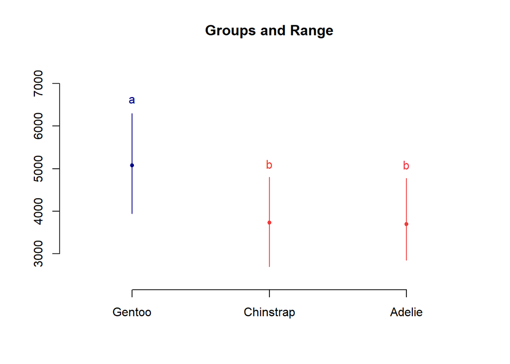

```r
# Gráfico de la función `kruskal()`
plot(k)
```

Y también podemos hacerlo con el paquete `ggplot2`, pero para esto debemos preparar nuestros datos.

```r
sumbm <- Summarize(body_mass_g ~ species, data = penguins)
sumbm
```

```
##     species   n nvalid     mean       sd  min     Q1 median   Q3  max
## 1    Adelie 152    151 3700.662 458.5661 2850 3350.0   3700 4000 4775
## 2 Chinstrap  68     68 3733.088 384.3351 2700 3487.5   3700 3950 4800
## 3    Gentoo 124    123 5076.016 504.1162 3950 4700.0   5000 5500 6300
```

Después agregamos una columna con el error estándar y una columna para el intervalo de confianza al 95%.

```r
sumbm$SE <- sumbm$sd / sqrt(sumbm$n)
sumbm$liIC95 <- sumbm$mean - sumbm$SE * 1.96
sumbm$lsIC95 <- sumbm$mean + sumbm$SE * 1.96
sumbm
```

```
##     species   n nvalid     mean       sd  min     Q1 median   Q3  max       SE
## 1    Adelie 152    151 3700.662 458.5661 2850 3350.0   3700 4000 4775 37.19462
## 2 Chinstrap  68     68 3733.088 384.3351 2700 3487.5   3700 3950 4800 46.60747
## 3    Gentoo 124    123 5076.016 504.1162 3950 4700.0   5000 5500 6300 45.27097
##     liIC95   lsIC95
## 1 3627.761 3773.564
## 2 3641.738 3824.439
## 3 4987.285 5164.747
```

Con estos datos procedemos a graficar.

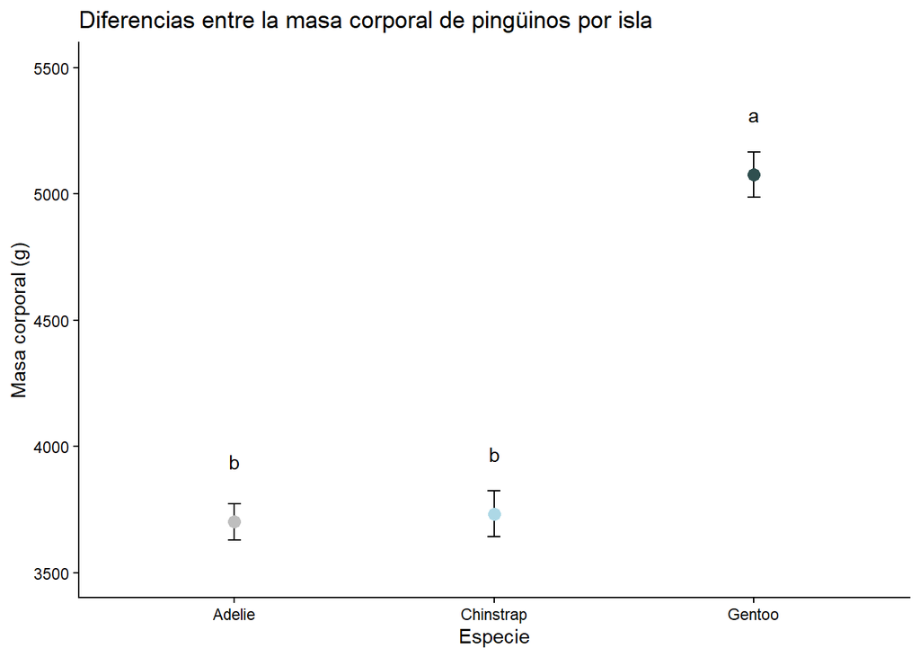

```r
ggplot(sumbm, aes(species, mean)) +
  geom_errorbar(width = 0.05,
                aes(ymin = liIC95,
                    ymax = lsIC95)) +
  geom_point(shape = 19,
             size = 3,
             color = c("gray", "lightblue", "darkslategray")) +
labs(title = "Diferencias entre la masa corporal de pingüinos por isla",
     y = "Masa corporal (g)",
     x = "Especie") +
  geom_text(aes(label = c("b", "b", "a")),
            vjust = -3.5) +
  ylim(c(3500, 5500)) +
  theme_classic()
```

```r
ggsave("Imagenes/kruskal.jpg")
```

En los gráficos también podemos graficar la significancia de las comparaciones con la función `geom_signif()` del complemento `ggsignif` para `ggplot2`:

[figure not shown]

```r
ggplot(sumbm, aes(species, mean)) +
  geom_errorbar(width = 0.05,
                aes(ymin = liIC95,
                    ymax = lsIC95)) +
  geom_point(shape = 19,
             size = 3,
             color = c("gray", "lightblue", "darkslategray")) +
  labs(title = "Diferencias entre la masa corporal de pingüinos por especie",
       y = "Masa corporal (g)",
       x = "Especie") +
  theme_classic() +
  geom_signif(data = penguins, aes(species, body_mass_g),
              comparisons = list(c("Adelie", "Chinstrap"),
                                 c("Adelie", "Gentoo"),
                                 c("Chinstrap", "Gentoo")),
              size = 0.5,
              map_signif_level = TRUE,
              y_position = c(3800,5300,5100),
              tip_length = 0.01)
```

Volver arriba

Inicio